# High-School Cybersecurity Standards & Instructional Design Evidence

## Professional analysis of the 51-jurisdiction standards matrix

**Version 2.0 · August 6, 2026**

This notebook turns the supplied workbook into a reproducible decision analysis for curriculum design, state localization, teacher implementation, product positioning, and pilot evaluation. It answers:

1. What cybersecurity knowledge and skills are expected of high-school students?
2. Which standards recur across jurisdictions?
3. Which state-specific standards or approval conditions require supplemental content?
4. Which teaching strategies improve knowledge, application, retention, and transfer?
5. What evidence exists specifically for K–12 cybersecurity instruction?
6. What broader STEM and learning-science evidence can reasonably be transferred?
7. Which course structures are feasible for teachers without deep cybersecurity backgrounds?
8. What device, network, privacy, and safety constraints affect hands-on work?
9. What do existing products cover, and what do they leave underserved?
10. What outcomes can be measured during a pilot?

> **Interpretation boundary.** The workbook is a planning and source inventory, not a completed 51-jurisdiction legal crosswalk. Exact state expectations are decomposed for seven jurisdictions. Cross-jurisdiction recurrence is therefore reported only for the explicit high-school subset of those seven jurisdictions, with the denominator shown throughout.

## What was improved from the first notebook

The first version was directionally useful and executed cleanly, but several important conclusions were manually authored rather than calculated. This revision makes the analysis more defensible and professional by:

- restricting state recurrence analysis to **explicit high-school exact expectations**;
- foregrounding data completeness and denominators before presenting findings;
- applying an auditable, multi-label cybersecurity-domain taxonomy across state, national, and AP records;
- distinguishing literal standard identifiers from normalized concepts that can be compared across frameworks;
- replacing broad keyword flags with field-specific evidence excerpts and an explicit “screening, not legal finding” label;
- separating direct K–12 cybersecurity evidence from transferable STEM and learning-science evidence;
- deriving course feasibility from the workbook's lesson and time models;
- coding the sampled product matrix with a transparent capability rubric rather than asserting a market-wide gap;
- converting the pilot section into a measurement plan, analysis protocol, data template, and decision framework; and
- exporting the underlying analytical tables so every chart and recommendation can be audited.

```
Workbook: Foundations_of_Cybersecurity_51_Jurisdiction_Standards_Matrix(1) (1).xlsx
Output directory: /mnt/data/cybersecurity_analysis_outputs
```

# 1. Data foundation, validation, and coverage

A professional standards analysis should show what is known, what is only inventoried, and what remains unresolved before interpreting recurrence. The checks below validate the workbook structure and reconcile its core record counts.

Workbook validation checks

| Check | Status | Detail |
| --- | --- | --- |
| State Matrix: required columns | PASS | All required columns present |
| State Classification: required columns | PASS | All required columns present |
| State Exact Detail: required columns | PASS | All required columns present |
| National Standards: required columns | PASS | All required columns present |
| AP Benchmark: required columns | PASS | All required columns present |
| AI-State Standards: required columns | PASS | All required columns present |
| 20-Module Course: required columns | PASS | All required columns present |
| Module-Lesson Map: required columns | PASS | All required columns present |
| Semester Time Model: required columns | PASS | All required columns present |
| Pedagogy Evidence: required columns | PASS | All required columns present |
| Research Sources: required columns | PASS | All required columns present |
| Competitor Matrix: required columns | PASS | All required columns present |
| Approval Checklist: required columns | PASS | All required columns present |
| Verification Register: required columns | PASS | All required columns present |
| Codebook: required columns | PASS | All required columns present |
| Jurisdiction count | PASS | 51 unique jurisdictions |
| State exact-row reconciliation | PASS | Matrix total 194; detail rows 194 |
| State exact identifiers unique | PASS | 0 duplicate state/ID pairs |
| National identifiers unique | PASS | 0 duplicate framework/ID pairs |
| AP objective identifiers unique | PASS | 0 duplicate AP objective IDs |
| Exact state source completeness | PASS | 0 rows missing an official source |
| Explicit high-school subset | PASS | 46 exact expectations across 7 jurisdictions |

51

Jurisdictions inventoried

Source-level policy and standards inventory

7/51

Exact high-school state coverage

13.7% of jurisdictions; recurrence denominator n=7

46

High-school exact expectations

Filtered from the 194 exact state expectations

183

Benchmarking records

46 state + 58 national + 79 AP

60 lessons

Core course design

20 modules; 55 core hours

Aug 01, 2026

Source verification date

Latest date recorded in the verification register

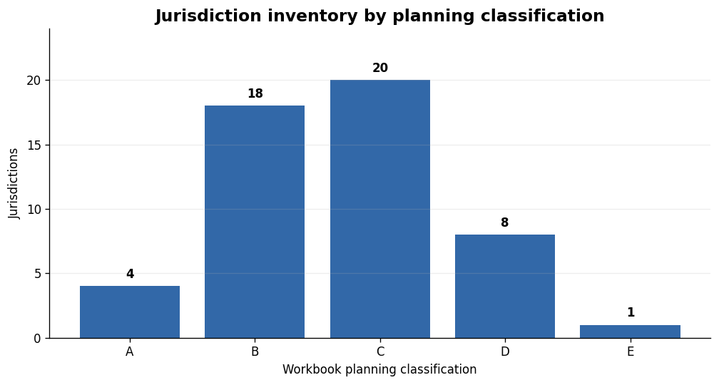

Confidence labels in the source inventory

| Confidence | Jurisdictions |
| --- | --- |
| Medium | 40 |
| Low | 8 |
| High | 3 |

Coverage conclusion

The workbook inventories all 51 jurisdictions, but only 7 have decomposed high-school expectations. The remaining 44 jurisdictions should be treated as research backlog—not as evidence that standards are absent. All recurrence results below therefore use n=7: Alabama, California, Florida, Louisiana, New York, North Dakota, Ohio.

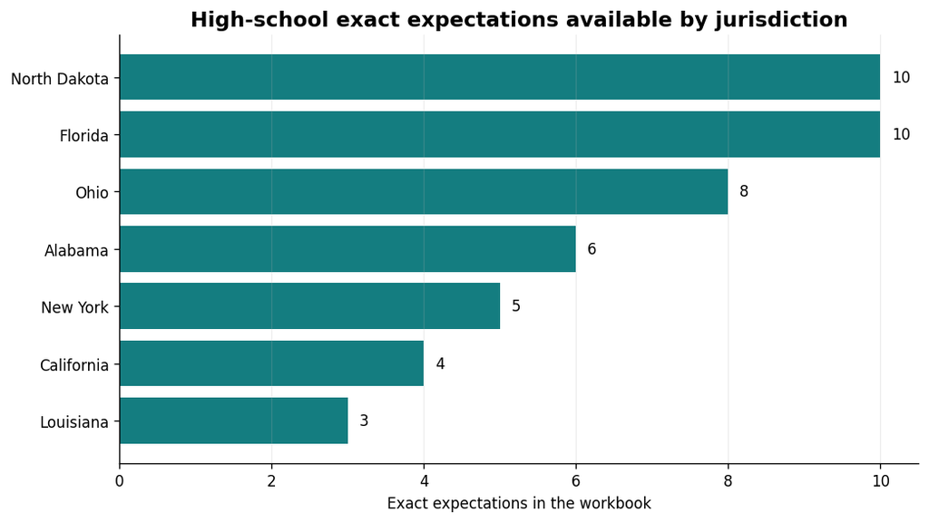

# 2. Expected high-school cybersecurity knowledge and skills

Frameworks rarely use identical identifiers or strand names. To compare them responsibly, the analysis applies a transparent **multi-label taxonomy** to the verbatim state expectations, national standards, and AP learning objectives. A record may map to more than one domain, so column totals do not sum to the number of records.

Taxonomy audit result

All 183 benchmarking records received at least one domain assignment; 0 were unmatched. Assignments are rule-based and multi-label. They should be reviewed when the workbook adds new wording or frameworks.

Random audit sample of taxonomy assignments

| Source | Jurisdiction | Record ID | Assigned domains | Assignment count |
| --- | --- | --- | --- | --- |
| State exact (HS) | Ohio | NI.C.9-12.A.c | Networks, cloud & IoT security; Threats, vulnerabilities & social engineering | 2 |
| AP benchmark | AP benchmark | 1.4.B | Security foundations, risk & controls; Threats, vulnerabilities & social engineering | 2 |
| National standards | National standards | S1-CYB-CP-12 | Security foundations, risk & controls; Governance, ethics, law & safe use | 2 |
| State exact (HS) | Ohio | NI.C.9-12.A.a | Networks, cloud & IoT security; Governance, ethics, law & safe use | 2 |
| AP benchmark | AP benchmark | 4.4.D | Computing systems, devices & hardening; Threats, vulnerabilities & social engineering; Monitoring, incident response & resilience | 3 |
| AP benchmark | AP benchmark | 2.1.E | Security foundations, risk & controls | 1 |
| AP benchmark | AP benchmark | 3.4.B | Security foundations, risk & controls; Networks, cloud & IoT security; Identity & access management | 3 |
| AP benchmark | AP benchmark | 5.6.A | Threats, vulnerabilities & social engineering; Monitoring, incident response & resilience | 2 |
| AP benchmark | AP benchmark | 2.1.D | Security foundations, risk & controls | 1 |
| National standards | National standards | S2-CYB-PP-11 | Threats, vulnerabilities & social engineering; Monitoring, incident response & resilience; Governance, ethics, law & safe use | 3 |
| AP benchmark | AP benchmark | 5.6.D | Threats, vulnerabilities & social engineering; Data protection, privacy & cryptography; Monitoring, incident response & resilience | 3 |
| AP benchmark | AP benchmark | 1.4.A | Security foundations, risk & controls; Threats, vulnerabilities & social engineering | 2 |

Normalized cybersecurity-domain coverage across the three evidence sources

| Domain | HS exact jurisdictions | HS state exact rows | National standards | AP objectives | HS exact prevalence |
| --- | --- | --- | --- | --- | --- |
| Security foundations, risk & controls | 6 | 13 | 29 | 64 | 86% |
| Threats, vulnerabilities & social engineering | 6 | 16 | 25 | 47 | 86% |
| Data protection, privacy & cryptography | 6 | 17 | 12 | 8 | 86% |
| Networks, cloud & IoT security | 4 | 18 | 30 | 20 | 57% |
| Identity & access management | 4 | 9 | 13 | 12 | 57% |
| Governance, ethics, law & safe use | 3 | 5 | 20 | 0 | 43% |
| Computing systems, devices & hardening | 3 | 10 | 19 | 17 | 43% |
| Monitoring, incident response & resilience | 2 | 5 | 22 | 25 | 29% |
| Secure software, scripting & automation | 2 | 2 | 4 | 1 | 29% |
| Communication, collaboration & careers | 0 | 0 | 19 | 5 | 0% |

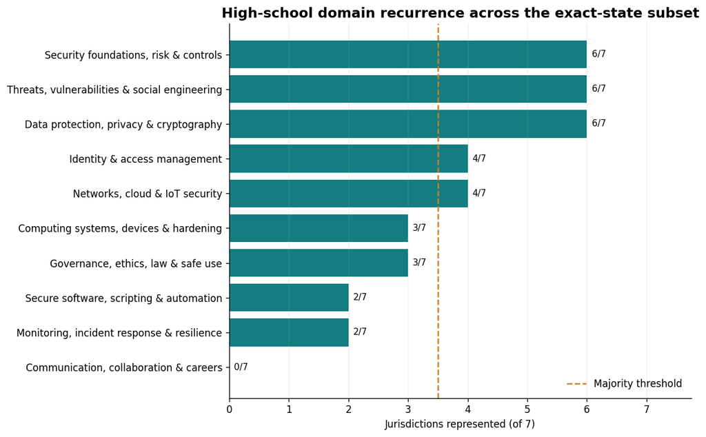

Observable performance demands in standards language

| Performance demand | State exact (HS) | National standards | AP benchmark | All records | All-record prevalence |
| --- | --- | --- | --- | --- | --- |
| Apply & configure | 14 | 15 | 28 | 57 | 31% |
| Analyze & evaluate | 14 | 25 | 17 | 56 | 31% |
| Recognize & describe | 13 | 10 | 31 | 54 | 30% |
| Explain & compare | 9 | 13 | 26 | 48 | 26% |
| Investigate & troubleshoot | 5 | 1 | 17 | 23 | 13% |
| Design & create | 8 | 8 | 2 | 18 | 10% |
| Collaborate & manage | 4 | 6 | 5 | 15 | 8% |
| Communicate & justify | 0 | 7 | 7 | 14 | 8% |

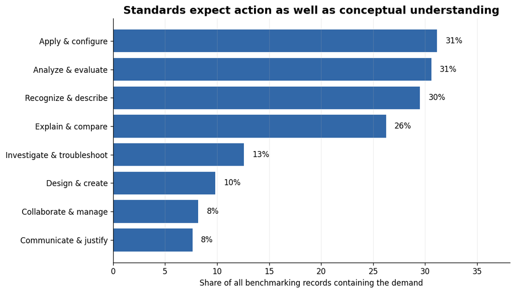

Expected high-school knowledge, skills, and evidence of performance

| Domain | HS exact jurisdictions | HS exact prevalence | National standards | AP objectives | Role in a foundations course | Observable student evidence |
| --- | --- | --- | --- | --- | --- | --- |
| Security foundations, risk & controls | 6 | 86% | 29 | 64 | Common-state core | Threat model, risk register, and control-selection rationale |
| Threats, vulnerabilities & social engineering | 6 | 86% | 25 | 47 | Common-state core | Indicator analysis, vulnerability finding, and mitigation plan |
| Data protection, privacy & cryptography | 6 | 86% | 12 | 8 | Common-state core | Data classification, privacy impact analysis, and protection decision |
| Networks, cloud & IoT security | 4 | 57% | 30 | 20 | Common-state core | Network diagram, packet/data-flow analysis, and architecture tradeoff |
| Identity & access management | 4 | 57% | 13 | 12 | Common-state core | Access-control model, authentication comparison, and least-privilege audit |
| Governance, ethics, law & safe use | 3 | 43% | 20 | 0 | National/AP-supported core or extension | Authorization memo, responsible-disclosure decision, policy, or ethics analysis |
| Computing systems, devices & hardening | 3 | 43% | 19 | 17 | National/AP-supported core or extension | Hardening baseline, change log, and remediation justification |
| Monitoring, incident response & resilience | 2 | 29% | 22 | 25 | National/AP-supported core or extension | Incident timeline, evidence interpretation, containment, and recovery plan |
| Secure software, scripting & automation | 2 | 29% | 4 | 1 | Targeted extension / local overlay | Code/configuration review, small defensive script, or automation artifact |
| Communication, collaboration & careers | 0 | 0% | 19 | 5 | National/AP-supported core or extension | Technical briefing, team handoff, documentation, and career reflection |

Answer: expected high-school profile

The standards describe more than awareness. Students are expected to explain and compare systems, apply and configure controls, analyze risks and evidence, investigate problems, create artifacts, and justify decisions within authorized and ethical boundaries. The strongest common-state spine in the exact subset consists of: Security foundations, risk & controls, Threats, vulnerabilities & social engineering, Data protection, privacy & cryptography, Networks, cloud & IoT security, Identity & access management. National and AP frameworks add depth in incident response, governance, system hardening, communication, and selected secure-software practices.

# 3. Which standards recur across jurisdictions?

Literal state identifiers do not recur because jurisdictions organize standards differently. The defensible comparison is therefore **concept recurrence after normalization**, not a claim that states adopted the same wording.

Cross-jurisdiction recurrence in the explicit high-school subset

| Domain | HS exact jurisdictions | HS exact prevalence | HS state exact rows | Recurrence tier |
| --- | --- | --- | --- | --- |
| Security foundations, risk & controls | 6 | 86% | 13 | Majority (4–7) |
| Threats, vulnerabilities & social engineering | 6 | 86% | 16 | Majority (4–7) |
| Data protection, privacy & cryptography | 6 | 86% | 17 | Majority (4–7) |
| Networks, cloud & IoT security | 4 | 57% | 18 | Majority (4–7) |
| Identity & access management | 4 | 57% | 9 | Majority (4–7) |
| Governance, ethics, law & safe use | 3 | 43% | 5 | Emerging (2–3) |
| Computing systems, devices & hardening | 3 | 43% | 10 | Emerging (2–3) |
| Monitoring, incident response & resilience | 2 | 29% | 5 | Emerging (2–3) |
| Secure software, scripting & automation | 2 | 29% | 2 | Emerging (2–3) |
| Communication, collaboration & careers | 0 | 0% | 0 | Limited (0–1) |

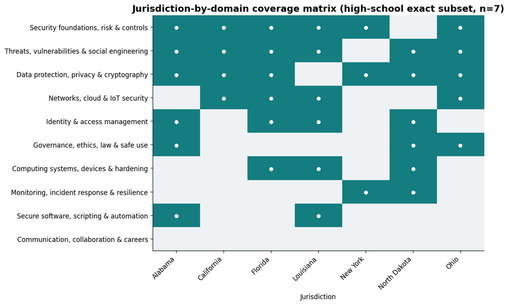

Answer: recurring standards spine

5 normalized domains appear in a majority of the 7 exact-state high-school subsets: Security foundations, risk & controls (6/7); Threats, vulnerabilities & social engineering (6/7); Data protection, privacy & cryptography (6/7); Networks, cloud & IoT security (4/7); Identity & access management (4/7). Less frequent in this limited subset are: Governance, ethics, law & safe use (3/7); Computing systems, devices & hardening (3/7); Monitoring, incident response & resilience (2/7); Secure software, scripting & automation (2/7); Communication, collaboration & careers (0/7). These lower counts should not be interpreted as low importance: national and AP frameworks add substantial depth, and 44 jurisdictions have not yet been decomposed.

# 4. State-specific standards and approval conditions requiring supplemental content

Two different localization problems must be managed separately:

1. **Content localization** — exact identifiers, named-course or CTE outcomes, state privacy/digital-citizenship requirements, AI-related expectations, credentials, or work-based learning.
2. **Approval localization** — course code and credit, instructional time, teacher assignment, pathway filing, assessment rules, facilities, privacy, accessibility, district security, acceptable use, and governance.

The screen below searches only specified workbook fields and preserves the evidence excerpt that triggered each flag. It is a research-prioritization screen, not a legal determination.

State-localization screening results

| Flag | Interpretation | Jurisdictions | Share of 51 |
| --- | --- | --- | --- |
| Research backlog \| Exact state identifiers unresolved | Complete exact extraction before claiming state coverage. | 44 | 86% |
| Approval \| Course code, credit, or graduation treatment | Attach the operative catalog/code/credit evidence for the filing. | 26 | 51% |
| Content \| Named course or CTE technical overlay | Compare the national core with the named course/pathway outcomes. | 22 | 43% |
| Approval \| Assessment or credential condition | Distinguish required, optional, and marketing-only credentials. | 20 | 39% |
| Content \| Privacy or digital-citizenship emphasis | Protect explicit privacy/citizenship content and state terminology. | 5 | 10% |
| Approval \| Facilities, device, network, or lab review | Resolve device capability, isolation, filtering, and IT approval. | 5 | 10% |
| Approval \| Teacher license or assignment rule | Verify assignment authority and any professional-learning condition. | 3 | 6% |
| Content \| Explicit high-school AI/cyber expectations | Add AI privacy, security, bias, misuse, and responsible-use expectations where applicable. | 2 | 4% |

Evidence excerpts supporting the screening flags

| Flag | Jurisdiction | Source field | Evidence excerpt |
| --- | --- | --- | --- |
| Approval \| Assessment or credential condition | Arizona | Assessment / technical standard | State technical standards and assessment blueprint |
| Approval \| Assessment or credential condition | California | Assessment / technical standard | Anchor and pathway standards; local assessment design |
| Approval \| Course code, credit, or graduation treatment | Alabama | Caution / filing check | Confirm local course code/credit and any 2026 CTE update before filing. |
| Approval \| Course code, credit, or graduation treatment | Alaska | Caution / filing check | Confirm graduation-credit classification locally. |
| Approval \| Facilities, device, network, or lab review | Arizona | Course-use decision | Use the academic standards for course approval and the Network Security program standards for CTE depth. |
| Approval \| Facilities, device, network, or lab review | Maryland | Caution / filing check | The program guide is labeled draft; verify final adoption and current program code. |
| Approval \| Teacher license or assignment rule | Michigan | Caution / filing check | …the course or earn CS credit. Any grade-band-certified teacher may be assigned when local evidence supports content competence; use correct REP/SCED reporting. Credit may be elective and may satisfy … |
| Approval \| Teacher license or assignment rule | South Dakota | Approval / Perkins / CLNA | …ocal CTE program approval, Perkins, CLNA, and educator endorsement requirements |
| Content \| Explicit high-school AI/cyber expectations | Alabama | AI-State Standards | IDs 9-12-36; 9-12-38; 9-12-41; 9-12-42. Example: Analyze the implications of data privacy and consent for making informed decisions about personal data security. |
| Content \| Explicit high-school AI/cyber expectations | North Dakota | AI-State Standards | IDs 9-10.E.1; 9-10.S.2; 11-12.E.1; 11-12.S.2. Example: Identify and explain ethical issues related to technology use (e.g., AI, privacy, location sharing, intellectual property) and the responsibility… |
| Content \| Named course or CTE technical overlay | Arkansas | Classification | B — State cybersecurity/IT CTE pathway |
| Content \| Named course or CTE technical overlay | California | Classification | B — State cybersecurity/IT CTE pathway |
| Content \| Privacy or digital-citizenship emphasis | Idaho | Cyber specificity | Includes cybersecurity, privacy, networks, and responsible computing |
| Content \| Privacy or digital-citizenship emphasis | Massachusetts | Cyber specificity | Includes privacy, security, networks, data, and digital citizenship |
| Research backlog \| Exact state identifiers unresolved | Alaska | Exact crosswalk status | Source inventory only — exact standard decomposition unresolved |
| Research backlog \| Exact state identifiers unresolved | Arizona | Exact crosswalk status | Source inventory only — exact standard decomposition unresolved |

Approval evidence baseline to complete for each target jurisdiction

| ID | Category | Required evidence |
| --- | --- | --- |
| 1 | Course identity | Title, description, grade span, prerequisites, credit value, minimum instructional time |
| 2 | Course coding | State course code, NCES SCED code, local code, subject/department classification |
| 3 | Graduation treatment | Elective/CTE/CS/math/science credit, substitution eligibility, applicable student cohort |
| 4 | Standards | Exact identifier, exact expectation, grade band, version, adoption/effective date, required/recommended status |
| 5 | Mapping evidence | Module, lesson, assessment artifact, full/partial/supporting/gap rating |
| 6 | Teacher assignment | License, endorsement, assignment code, exception, professional-learning expectation |
| 7 | CTE program | Sequence, pathway position, CIP code, Perkins eligibility, CLNA/local plan connection |
| 8 | Technical assessment | Required or optional credential, assessment code, testing rules, pass threshold |
| 10 | Facilities | Device specifications, virtualization, cyber range, software, network isolation, egress controls |
| 11 | Approval authority | State versus local authority, form, approving body, review cycle, deadline, public-material review |
| 12 | Student privacy | FERPA, COPPA, state student-data law, DPA, retention/deletion, subprocessors |
| 13 | Accessibility | WCAG 2.2 AA, Section 504, ADA, captions, keyboard access, assistive-technology evidence |
| 14 | Licensing and AUP | Software licenses, acceptable use, authorization, safe-target rules, vulnerability disclosure |
| 15 | District IT/security | Security review, firewall/allowlist, account provisioning, incident escalation, isolation |
| 16 | AI and integrity | Approved AI uses, student-data limits, attribution, human validation, academic integrity |
| 17 | Equity and access | Multilingual learner supports, accommodations, offline/low-bandwidth alternative, inclusive examples |
| 18 | Parent transparency | Syllabus/material access, consent/notice, opt-out or alternative activity where required |
| 19 | Evaluation | Implementation fidelity, knowledge, performance, transfer, belonging, delayed retention, subgroup review |

Jurisdictions with the most issue types surfaced by this screen

| Jurisdiction | Screened issue types |
| --- | --- |
| South Dakota | 5 |
| Michigan | 4 |
| Oklahoma | 4 |
| North Carolina | 4 |
| West Virginia | 4 |
| Utah | 4 |
| Texas | 4 |
| Louisiana | 3 |
| Washington | 3 |
| New York | 3 |
| North Dakota | 3 |
| Missouri | 3 |
| Kentucky | 3 |
| New Hampshire | 3 |
| Nevada | 3 |

Answer: supplemental content and approval conditions

The largest research need is exact extraction for 44 jurisdictions. The workbook also identifies 22 jurisdictions in named-course or CTE-overlay classifications, and explicit high-school AI/cyber expectations in Alabama, North Dakota. Approval cannot be inferred from standards alignment alone: each filing needs evidence for course code/credit, teacher assignment, instructional time, pathway/Perkins treatment when applicable, assessments or credentials, facilities and network controls, privacy, accessibility, acceptable use, district security, AI governance, and evaluation.

# 5. Teaching strategies and the evidence base

The evidence must be stratified by **directness**. K–12 cybersecurity studies are most relevant but relatively small and heterogeneous. Broader STEM and learning-science findings are stronger in several areas, but they should be transferred only when the learning mechanism and classroom conditions match.

8

Workbook pedagogy practices

Research-grounded design practices in the supplied workbook

6

Workbook research sources

Cybersecurity and curriculum-alignment sources supplied

Pedagogy evidence register supplied in the workbook

| Practice | Evidence synthesis | Course design rule | Evidence strength / caveat |
| --- | --- | --- | --- |
| Scenario-first, problem-centered instruction | Systematic and design literature supports authentic, contextual problems; the supplied high-school guideline and AP framework consistently organize knowledge around decisions and scenarios. | Open each module with a consequential scenario; end with an evidence-backed decision or artifact. | Moderate; outcome studies remain heterogeneous. |
| Scaffolded hands-on labs in isolated environments | Quasi-experimental and virtual-lab studies report knowledge and self-efficacy gains; cyber-range/game reviews warn that engagement alone is not mastery. | Use concept briefing → modeled example → guided lab → independent variation → explanation; never target public systems. | Moderate for proximal learning; limited long-term/transfer evidence. |
| CTF and games as retrieval/application, not the entire course | CTFs can increase interest and provide authentic problem solving, while reviews find uneven learning design and shallow conceptual coverage in many games. | Use short challenges after instruction and a capstone competition; score reasoning, evidence, and reflection in addition to flags. | Promising but mixed. |
| Authentic performance assessment | Course and CTE quality standards emphasize observable competencies, aligned assessment, feedback, and real-world application. | Require logs, diagrams, code, policies, incident timelines, and briefings with analytic rubrics. | Strong design consensus; cyber-specific causal evidence is limited. |
| Spaced retrieval, interleaving, and delayed retention | General learning science strongly supports retrieval and spacing; the high-school cyber evidence base rarely measures delayed retention. | Use cumulative checks every module, mixed-domain labs every four modules, and a delayed post-course measure. | Strong general evidence; cyber-specific implementation evidence needed. |
| Collaborative roles plus individual accountability | Cyber learning is collaborative, but group-composition effects can alter self-efficacy and interest. | Rotate analyst, operator, recorder, and briefer roles; collect an individual explanation from every student. | Moderate. |
| Low floor, high ceiling, and belonging-centered design | CSTA/AI4K12 and pathway guidance prioritize inclusive collaboration, accessible entry points, relevant contexts, and belonging. | Provide novice path, extension path, multiple artifact formats, accessible labs, and culturally relevant scenarios without lowering standards. | Strong expert consensus; measure subgroup outcomes. |
| Teacher enablement and stable lab operations | Program-quality and online-course standards identify professional development, support, usability, and technology reliability as implementation conditions. | Provide prebuilt environments, troubleshooting trees, answer keys, misconception notes, safety scripts, and implementation rehearsals. | Strong implementation consensus. |

Research-source register supplied in the workbook

| Study | Relevant finding | Source URL |
| --- | --- | --- |
| Ibrahim et al. — Cybersecurity education for children: a systematic literature review | Reviewed 24 academic and 19 gray-literature sources; secondary-level work dominates and cybersecurity is not taught systematically across schools. | https://ro.ecu.edu.au/ecuworks2022-2026/3929/ |
| Namukasa et al. — Hands-on IoT cybersecurity course | Quasi-experimental middle/high-school study reported significant knowledge gains, F(1,16)=15.76, p=.001, partial eta squared=.496; self-efficacy/interest effects and group composition require cautious… | https://digitalcommons.kennesaw.edu/jcerp/vol2025/iss1/9/ |
| Konak — inquiry-based virtual cybersecurity lab | Hands-on inquiry lab reported significant learning progress and gains in self-efficacy; supports guided experimentation with reflection. | https://digitalcommons.kennesaw.edu/jcerp/vol2018/iss1/6/ |
| Coenraad et al. — Cybersecurity games systematic review | Many games use thin narratives and surface-level cyber-safety content; fewer support deep conceptual engagement or inquiry. | https://journals.sagepub.com/doi/10.1177/1046878120933312 |
| Systematic scoping review of game-based cybersecurity education | Games and ranges can support learning when aligned to objectives and assessment; adaptive difficulty and valid mastery measures remain important gaps. | https://doi.org/10.1007/s10207-026-01239-9 |
| CSTA Standards Alignment Review (supplied PDF) | Popular curricula overrepresent algorithms/programming and underrepresent computing systems, networks, and cybersecurity; the course should deliberately protect time for under-covered domains. | Standards-Alignment-Review.pdf |

Evidence specific to K–12 cybersecurity or closely related cyber-learning environments

| Evidence | Population / design | Main signal | What it supports | What it does not establish | Directness | Source |
| --- | --- | --- | --- | --- | --- | --- |
| Ibrahim et al. (2024) — systematic review of K–12 cybersecurity education | Systematic review; 24 academic and 19 gray-literature sources across K–12 | Secondary-level work dominates; cybersecurity is not taught systematically across schools. | Need for coherent curriculum architecture, clearer outcomes, and better school-based evaluation. | Does not estimate the causal effect of a particular course model. | High for landscape; low for intervention effect | https://doi.org/10.1109/ACCESS.2024.3393425 |
| Namukasa et al. (2025) — hands-on IoT cybersecurity course | Middle/high-school, eight-module, quasi-experimental within-subject design | Significant proximal knowledge gain, F(1,16)=15.76, p=.001, partial eta²=.496; motivation results varied. | Guided, hands-on modules can improve near-term knowledge in a school setting. | Small study; no strong claim about delayed retention, far transfer, or broad scalability. | Direct K–12 cyber; small/proximal | https://digitalcommons.kennesaw.edu/jcerp/vol2025/iss1/9/ |
| Konak (2018) — inquiry-based virtual cybersecurity lab | K–12 outreach program with guided virtual-lab inquiry and pre/post evaluation | Reported learning progress and gains in self-efficacy. | Virtual labs can support guided experimentation when paired with reflection. | Weeklong/proximal evaluation does not establish semester-long retention or transfer. | Direct K–12 cyber; program evaluation | https://digitalcommons.kennesaw.edu/jcerp/vol2018/iss1/6/ |
| Coenraad et al. (2020) — review of cybersecurity digital games | Systematic review of 181 cybersecurity games and game-like experiences | Many experiences emphasize surface-level safety or thin gamification; fewer provide deep inquiry and conceptual engagement. | Use games/CTFs as purposeful practice tied to objectives, reasoning, and assessment. | Engagement or flag capture alone is not evidence of mastery or transfer. | Cyber-specific; mixed age groups | https://journals.sagepub.com/doi/10.1177/1046878120933312 |
| Game-based cybersecurity education scoping review (2026) | Scoping review of 230 studies; most participants were industry or undergraduate learners | Children are an emerging minority; standardized tests, comparison conditions, and mixed methods remain needed. | Align game mechanics to learning objectives and collect valid mastery evidence. | The broad literature cannot be treated as direct K–12 effectiveness evidence. | Cyber-specific; mostly non-K–12 | https://doi.org/10.1007/s10207-026-01239-9 |
| CSTA Standards Alignment Review (supplied source) | Curriculum-to-standards alignment review, not an outcome study | Popular CS curricula may overrepresent programming and underrepresent systems, networks, and cybersecurity. | Protect instructional time for systems, networks, security, and impacts rather than allowing programming to crowd them out. | Alignment coverage is not evidence that students learned the material. | Direct to curriculum coverage; not causal | Supplied PDF summarized in the workbook |

Broader STEM and learning-science evidence that can reasonably inform course design

| Principle | Evidence base | Reasonable transfer | Boundary | Source |
| --- | --- | --- | --- | --- |
| Retrieval practice | Yang et al. (2021): meta-analysis of 222 studies and 48,478 students; overall classroom benefit g≈0.50. | Frequent low-stakes recall, cumulative checks, and retrieval before re-teaching. | Retrieval strengthens accessible memory; it does not replace authentic application or transfer tasks. | https://doi.org/10.1037/bul0000309 |
| Distributed practice / spacing | Cepeda et al. (2006): quantitative synthesis of 317 experiments; later classroom review also reports a moderate benefit. | Revisit identity, network, risk, and incident concepts across modules and include delayed checks. | Spacing schedule should match the intended retention interval; simple repetition is insufficient. | https://doi.org/10.1037/0033-2909.132.3.354 |
| Worked examples and scaffold fading | Atkinson et al. (2000): review of worked-example research in problem solving. | Model one complete analysis or configuration, guide a second, then fade prompts for an independent variant. | Students must explain decisions and eventually solve without the template. | https://doi.org/10.3102/00346543070002181 |
| Guided inquiry | Lazonder & Harmsen (2016): meta-analysis showing that guidance materially supports inquiry learning. | Use bounded questions, safe datasets, hints, checkpoints, and reflection in labs. | Unguided discovery is a poor default for novice learners and non-specialist teachers. | https://doi.org/10.3102/0034654315627366 |
| Inquiry-based science instruction | Furtak et al. (2012): meta-analysis of 37 K–12 studies; mean effect around 0.50, with teacher guidance important. | Organize investigations around evidence, explanation, and justified decisions—not tool manipulation alone. | Cybersecurity tasks must still be explicitly authorized, isolated, and technically supported. | https://doi.org/10.3102/0034654312457206 |
| Active learning | Freeman et al. (2014): 225 undergraduate STEM studies; average exam improvement about 0.47 SD. | Use explanation, peer reasoning, prediction, troubleshooting, and short practice throughout instruction. | The population is higher education; use as design support, not direct K–12 cyber proof. | https://doi.org/10.1073/pnas.1319030111 |
| Formative feedback | Wisniewski et al. (2020): meta-analysis of 435 studies; average effect around d=0.48 with substantial heterogeneity. | Give timely, task-specific feedback on reasoning, evidence, configurations, and revision. | Praise or scores alone are weaker than actionable information tied to the task and next step. | https://doi.org/10.3389/fpsyg.2019.03087 |
| Transfer through comparison and reflection | How People Learn II synthesizes evidence that transfer improves when learners compare cases, use models, and reflect on when knowledge applies. | Change scenario surface features, ask students to select methods, contrast solutions, and justify adaptation. | Retention measures alone cannot substantiate far transfer. | https://doi.org/10.17226/24783 |

Teaching strategy × outcome × evidence interpretation

| Outcome | Primary teaching strategy | Cybersecurity-specific evidence | Transferable evidence | Confidence | Pilot measure |
| --- | --- | --- | --- | --- | --- |
| Knowledge | Scenario-first explicit teaching; vocabulary; worked examples; concept maps | K–12 cyber studies support proximal knowledge gains from structured hands-on instruction. | Worked examples, active learning, and feedback | Moderate | Parallel standards-aligned pre/post assessment |
| Application | Modeled → guided → independent isolated labs; authentic artifacts and rubrics | Direct school studies support guided labs, but samples are small. | Guided inquiry, formative feedback, deliberate practice | Moderate | Common performance tasks scored with analytic rubrics |
| Retention | Spaced retrieval, cumulative checks, interleaving, delayed practice | Rarely measured directly in K–12 cybersecurity. | Strong retrieval and spacing evidence | Moderate overall; low cyber-specific | Delayed parallel assessment 4–8 weeks later |
| Transfer | Contrasting cases, novel scenarios, reflection, fading scaffolds, capstone briefing | Far transfer is rarely measured in school cybersecurity studies. | Comparison, abstraction, models, and guided inquiry | Moderate mechanism; low cyber-specific | Novel scenario requiring method selection and justification |
| Motivation | Short CTF/game challenges after instruction; meaningful roles; inclusive contexts | Games can improve engagement, but design quality and mastery evidence are uneven. | Autonomy, relevance, collaborative learning | Promising but mixed | Interest/belonging plus learning measures—not engagement alone |
| Implementation fidelity | Prebuilt labs, teacher primers, scripts, answer keys, troubleshooting trees, rehearsal | Implementation studies imply the need, but causal evidence is limited. | Cognitive load and implementation-support principles | Practice-grounded | Prep time, fidelity checks, support tickets, lesson completion |

Answer: evidence-based teaching model

Use scenario-first explicit instruction, worked examples, scaffolded isolated labs, authentic artifacts, timely feedback, and cumulative retrieval. For retention, space and revisit core concepts; for transfer, change scenario features, compare cases, fade scaffolds, and require students to select and justify methods. Use CTFs and games as application or retrieval—not as the entire curriculum. The direct K–12 cyber evidence is promising but still too limited to claim durable transfer without a delayed and novel-task pilot measure.

# 6. Course structures feasible for non-specialist teachers

Feasibility depends on a stable instructional routine, protected setup/assessment time, safe preconfigured environments, and teacher-facing diagnostics. The workbook's course architecture contains 20 modules, 60 lessons, and 3,300 core minutes.

Instructional-time feasibility derived from the workbook

| Model | Periods | Minutes each | Hours | Buffer hours | Equivalent buffer periods | Use / constraint |
| --- | --- | --- | --- | --- | --- | --- |
| Compressed implementation | 60 | 55 | 55.0 | 0.0 | 0.0 | Only where local policy accepts this instructional time for 0.5 credit; no national approval claim. |
| Daily semester | 90 | 55 | 82.5 | 27.5 | 30.0 | Default design: 60 module periods plus 30 lab, assessment, reteach, and capstone periods. |
| 90-hour expansion | 98 | 55 | 89.8 | 34.8 | 38.0 | Add eight documented studio/assessment periods where a 90-hour target is required; verify exact state/local rule. |
| Block schedule equivalent | 60 | 90 | 90.0 | 35.0 | 23.3 | Twenty modules × three 90-minute lesson blocks; account separately for calendar, testing, and interruptions. |

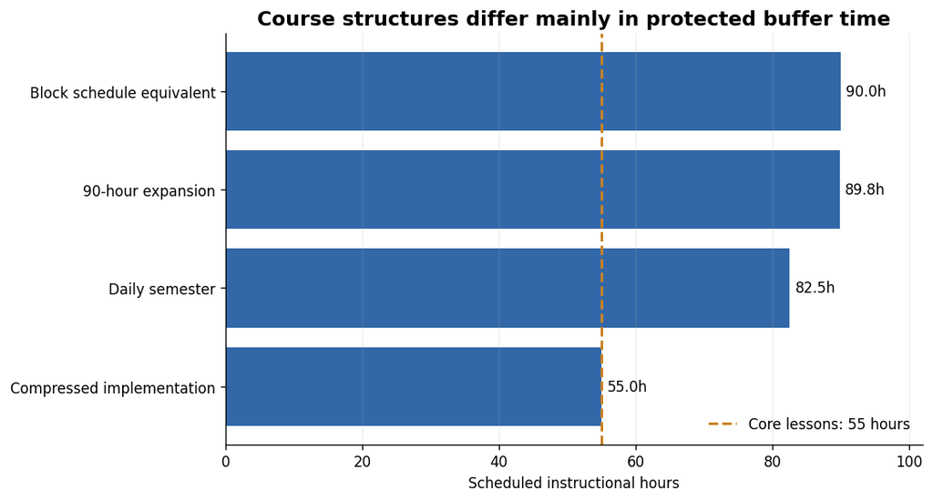

Recommended repeated lesson routine for a non-specialist teacher

| Phase | Repeated lesson routine | Instructional purpose | Teacher-facing support |
| --- | --- | --- | --- |
| 1 | Scenario and authorization frame | Establish purpose, scope, safety, and the consequential decision. | Scenario brief, target boundary, safety script |
| 2 | Concept briefing and worked example | Teach the mental model and model a complete analysis or configuration. | Concise primer, annotated example, misconception notes |
| 3 | Guided isolated practice | Students act in a resettable environment with checkpoints and hints. | Prebuilt lab, answer checkpoints, troubleshooting tree |
| 4 | Independent variation | Change evidence or constraints so students must adapt rather than copy. | Variant dataset/target, fading prompts, extension path |
| 5 | Artifact and explanation | Students produce evidence and justify choices with a rubric. | Artifact template, analytic rubric, exemplar/non-example |
| 6 | Retrieval and connection | Revisit prior concepts and connect the lesson to later modules. | Cumulative questions, exit prompt, delayed item bank |

Minimum viable teacher-enablement package

| Teacher-enablement component | Minimum professional specification |
| --- | --- |
| Content readiness | 10–15 minute teacher primer, key vocabulary, mental model, anticipated misconceptions |
| Lab readiness | One-click or preconfigured environment, reset instructions, known-good output, offline fallback |
| Safety | Authorization script, safe-target rules, prohibited actions, incident escalation path |
| Instruction | Facilitation notes, worked example, checks for understanding, pacing options |
| Troubleshooting | Decision tree organized by symptom, screenshot/log examples, escalation threshold |
| Assessment | Rubric, answer key, calibration examples, feedback language, reassessment path |
| Differentiation | Low-floor entry, accessibility supports, multilingual vocabulary, extensions |
| Professional learning | Short rehearsal, sandbox access, office hours/community, update notices |

Answer: feasible course structure

The most defensible default is the daily-semester model: 60 core lesson periods plus 30 periods for setup, extended labs, assessment, reteaching, interruption recovery, and capstone work. The 55-hour compressed model has no buffer and should be offered only where local policy permits and the implementation deliberately narrows variation. Block or 90-hour models provide more robust practice time. A repeated routine and strong teacher package are more important to non-specialist feasibility than adding more content.

# 7. Device, network, privacy, accessibility, and safety constraints

Hands-on cybersecurity is feasible in schools only when technical design is treated as a governed instructional system. The workbook's approval checklist identifies the core controls; the lab-mode matrix translates them into implementation choices.

Operational controls derived from the approval checklist

| ID | Category | Required evidence | Required operating decision |
| --- | --- | --- | --- |
| 10 | Facilities | Device specifications, virtualization, cyber range, software, network isolation, egress controls | Choose device floor, virtualization/range mode, isolation, reset, and egress design before procurement. |
| 12 | Student privacy | FERPA, COPPA, state student-data law, DPA, retention/deletion, subprocessors | Minimize accounts and student data; document retention, deletion, subprocessors, and vendor access. |
| 13 | Accessibility | WCAG 2.2 AA, Section 504, ADA, captions, keyboard access, assistive-technology evidence | Validate keyboard access, captions, screen-reader flow, color-independent cues, and alternatives. |
| 14 | Licensing and AUP | Software licenses, acceptable use, authorization, safe-target rules, vulnerability disclosure | Use only licensed tools and explicitly authorized targets; publish the lab compact and disclosure rules. |
| 15 | District IT/security | Security review, firewall/allowlist, account provisioning, incident escalation, isolation | Pre-approve allowlists, firewall/proxy behavior, provisioning, logging, and escalation with district IT. |
| 16 | AI and integrity | Approved AI uses, student-data limits, attribution, human validation, academic integrity | Define approved AI uses, prohibited data, attribution, verification, and integrity expectations. |
| 17 | Equity and access | Multilingual learner supports, accommodations, offline/low-bandwidth alternative, inclusive examples | Provide low-bandwidth/offline alternatives and equivalent learning paths for device constraints. |
| 18 | Parent transparency | Syllabus/material access, consent/notice, opt-out or alternative activity where required | Make the syllabus, tools, data practices, and alternative activities visible to families where required. |

Lab-mode decision matrix

| Lab mode | Device burden | Network/IT burden | Privacy posture | Safety posture | Best fit | No-go condition |
| --- | --- | --- | --- | --- | --- | --- |
| Approved browser-hosted range | Low–medium; modern browser | Medium–high: allowlists, ports, proxies, certificates, identity | Vendor accounts/telemetry require review | Strong when tenant and targets are isolated and resettable | 1:1 devices; districts able to approve a vendor | No approved data agreement, blocked traffic, or unclear tenant isolation |
| Local VM or container image | High: RAM, storage, virtualization/admin rights | Low–medium after image distribution | Can minimize external data transfer | Strong when host-only networks, snapshots, least privilege, and reset are enforced | Labs needing richer system/network control | Virtualization disabled, unmanaged images, or any route to production systems |
| Offline simulation / packet capture / emulator | Low–medium | Low; can work without live egress | Minimal account/data exposure | Very strong for introductory analysis; no live target required | Shared devices, filtered networks, fallback or accessibility path | Used as the only mode when objectives require real configuration and troubleshooting |

Hands-on launch gate

| Go/no-go control | Minimum condition before hands-on launch |
| --- | --- |
| Authorization | Every activity identifies authorized targets, allowed actions, prohibited actions, and stop conditions. |
| Isolation | No scanning, exploitation, credential use, or configuration changes against public or district production systems. |
| Identity and privacy | Use synthetic data and least-privilege accounts; do not use real student passwords, secrets, or sensitive records. |
| Reset and recovery | Each environment is resettable; known-good state and recovery instructions are documented. |
| Visibility and escalation | Teacher/district personnel can identify failures, logs, and suspected misuse and know who to contact. |
| Accessibility and equity | An equivalent path exists for students who cannot use virtualization, home internet, or a specific interface. |

Answer: constraints affecting hands-on work

The largest constraints are not the cybersecurity concepts themselves; they are device capability, virtualization/admin rights, filtering and egress, account provisioning, vendor data practices, accessibility, safe-target authorization, environment reset, and district incident escalation. A professional product should support at least two modes—an approved browser range and an offline/isolated alternative—so schools can preserve the learning objective when local infrastructure differs.

# 8. Existing product coverage and underserved needs

The workbook compares six representative routes. This is a **sampled landscape**, not an exhaustive market census, procurement review, privacy audit, or pricing comparison. Capability statuses below are generated from the workbook descriptions using explicit keyword rules.

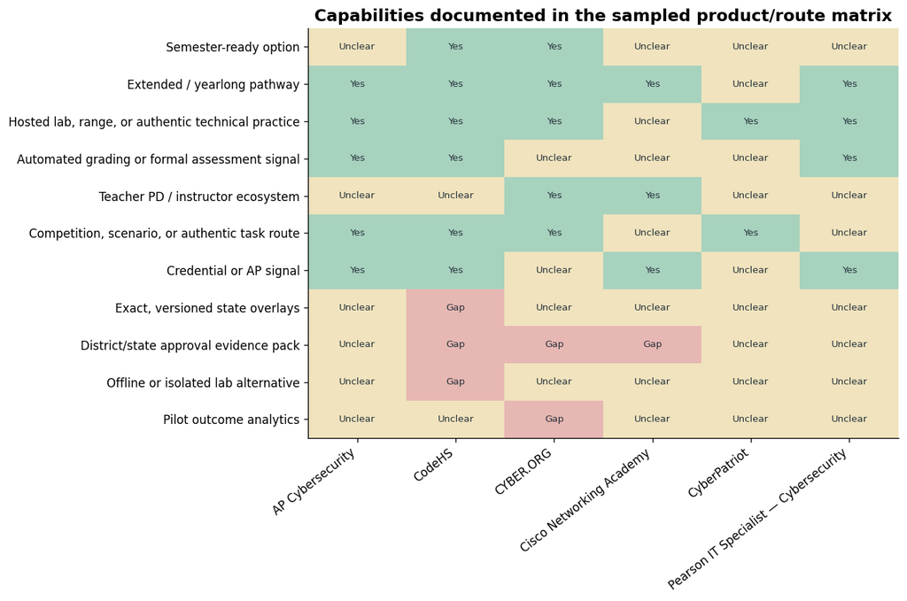

Capability coverage in the six-route sample

| Capability | Documented routes | Gap named | Not established / route-dependent |
| --- | --- | --- | --- |
| Exact, versioned state overlays | 0 | 1 | 5 |
| Offline or isolated lab alternative | 0 | 1 | 5 |
| Pilot outcome analytics | 0 | 1 | 5 |
| District/state approval evidence pack | 0 | 3 | 3 |
| Semester-ready option | 2 | 0 | 4 |
| Teacher PD / instructor ecosystem | 2 | 0 | 4 |
| Automated grading or formal assessment signal | 3 | 0 | 3 |
| Competition, scenario, or authentic task route | 4 | 0 | 2 |
| Credential or AP signal | 4 | 0 | 2 |
| Extended / yearlong pathway | 5 | 0 | 1 |
| Hosted lab, range, or authentic technical practice | 5 | 0 | 1 |

Workbook product/route sample and positioning evidence

| Provider / route | Route | Duration | Strengths | Implementation burden | Product positioning | Source |
| --- | --- | --- | --- | --- | --- | --- |
| AP Cybersecurity | Yearlong AP academic course; Course Audit | Yearlong; 2026–27 launch | Detailed five-unit framework, three assessed technical skill categories, collaboration including AI, scenario connections, external AP brand. | AP authorization, teacher/school readiness, yearlong schedule, cyber-range access, AP assessment alignment. | Use the proposed semester course as a broad-access feeder or non-AP alternative; do not imply AP equivalence. | https://apcentral.collegeboard.org/courses/ap-cybersecurity |
| CodeHS | Commercial hosted curriculum; elective/state variants/AP | Semester and full-year options; Alberti intro listed at 90 contact hours; AP listed at 130 contact hours | Hosted LMS, many variants, automatic grading, cyber-range/labs, published alignments. | Licensing, platform procurement, local alignment validation, device/network requirements. | Differentiate with approval-grade evidence packs, exact state overlays, transparent version control, and flexible offline/isolated labs. | https://codehs.com/curriculum/cybersecurity |
| CYBER.ORG | No-cost K–12 curriculum and cyber range | Cybersecurity 1/2 listed as 180 hours; Cyber Society about 90 hours | No-cost access, standards, professional development, cyber range, national reach. | Teacher onboarding, local course packaging and approval, range/network approvals. | Compete on complete semester packaging, state submission artifacts, assessment analytics, AI literacy, and implementation support—not on price alone. | https://cyber.org/find-curricula |
| Cisco Networking Academy | Free/low-cost digital courses and broader academy pathway | Intro to Cybersecurity is a short beginner course; longer career pathways available | Global brand, networking depth, career pathway, instructor ecosystem. | Academy/platform setup; short intro is not by itself a semester approval package. | Offer stronger academic standards mapping, pedagogy, student artifacts, and district-approval evidence. | https://www.netacad.com/courses/introduction-to-cybersecurity |
| CyberPatriot | Competition and extracurricular/team program | Seasonal competition; not a full semester curriculum | Authentic OS hardening/networking tasks, motivation, teamwork, national visibility. | Coach time, competition logistics, uneven access; narrower content coverage. | Integrate optional CyberPatriot-style capstones while preserving complete foundational CS, policy, privacy, AI, and assessment coverage. | https://www.uscyberpatriot.org/ |
| Pearson IT Specialist — Cybersecurity | Industry credential/exam objectives | Objectives recommend approximately 150 hours of instruction and hands-on experience | Clear five-domain credential target and employment signal. | Exam fees, testing center/logistics, substantial instructional time, credential-driven scope. | Use as an optional extended-course credential target; a semester foundation should not promise full 150-hour preparation. | User-supplied Pearson objective PDF |

Answer: product coverage and underserved bundle

The sampled routes collectively cover rigorous academic frameworks, hosted curricula, ranges, networking pathways, competitions, professional development, and credential signals. The capabilities least established in the workbook sample are: Exact, versioned state overlays, Offline or isolated lab alternative, Pilot outcome analytics, District/state approval evidence pack. The defensible product opportunity is therefore a bundled, semester-ready foundation with exact and version-controlled state overlays, filing artifacts, strong teacher enablement, safe flexible lab modes, privacy/accessibility governance, and pilot-ready analytics. This is an inference from six sampled routes—not a claim that no provider offers any individual feature.

# 9. Pilot outcomes, measurement plan, and analysis protocol

A pilot should test learning, transfer, implementation, safety, technical reliability, equity, and approval readiness. Satisfaction and completion are useful implementation indicators but are not substitutes for evidence of learning.

Professional pilot measurement plan

| Outcome family | Instrument / evidence | Timing | Unit | Primary analysis | Decision rule guidance |
| --- | --- | --- | --- | --- | --- |
| Knowledge — overall and by domain | Parallel standards-aligned assessment with domain subscores | Pre, post, delayed | Student | Paired mean change, 95% CI, paired effect size; item/domain diagnostics | Pre-register a positive-change gate and minimum domain coverage; do not use normalized gain as the sole statistic |
| Application | Two common performance tasks: e.g., risk/control analysis and network/incident task | Midpoint and capstone | Student/task | Rubric means, proficiency rate, revision gain; double-score a sample | Pre-register proficiency standard and acceptable inter-rater reliability |
| Delayed retention | Parallel knowledge form plus selected repeated task elements | 4–8 weeks after instruction/course | Student | Delayed score and retained proportion of post-minus-pre gain | Pre-register an acceptable retention range and report uncertainty |
| Transfer | Novel scenario with changed surface features requiring method selection and justification | Capstone or delayed | Student | Analytic rubric: representation, evidence, method choice, mitigation, justification | Require reasoning and adaptation; do not count a rehearsed replica as transfer |
| Safety and ethics | Authorization/privacy scenario items; lab compact; incident and near-miss log | Continuous | Student/class | Decision accuracy, violations, near misses, corrective actions | Zero unauthorized targeting; every near miss reviewed and closed |
| Self-efficacy, interest, belonging | Brief validated or carefully piloted scales plus open response | Pre, midpoint, post | Student | Change and subgroup patterns; reliability of scale | Secondary outcome only; never substitute for knowledge/performance |
| Engagement and completion | Attendance, lesson completion, attempts, revisions, time-on-task | Continuous | Student/class | Rates, distributions, relationship to learning outcomes | Use diagnostically; high engagement without learning is not success |
| Teacher feasibility | Preparation minutes, troubleshooting minutes, support contacts, confidence, fidelity checklist | Weekly and post | Teacher/lesson | Median and trend by module; completion and deviation reasons | Pre-register a sustainable prep/support target after initial onboarding |
| Technical reliability | Login, launch, reset, blocked traffic, device failure, uptime, IT escalation | Each lab | Session/class | Launch success, failure rate, time lost, root-cause categories | Pre-register launch and uptime targets; no unresolved critical security issue |
| Equity and accessibility | Access failures, accommodations, equivalent-path use, subgroup growth and experience | Continuous/post | Student/subgroup | Disaggregated outcomes with small-cell suppression; missingness review | No systematic access barrier; equivalent path must preserve the learning objective |
| Approval readiness | Completed standards map, checklist evidence, safety/privacy artifacts, version register | Before and after pilot | Jurisdiction/site | Percent resolved; unresolved stop conditions | No marketing or approval claim while a stop condition remains unresolved |
| Cost and scalability | Licenses, devices, PD/support hours, IT setup, reusable effort, cost per completer | End of pilot | Site/course | Total and marginal cost; sensitivity by class size and lab mode | Pre-register acceptable total cost and support burden for scale |

Pilot data-template notes

| Field | Definition | Type |
| --- | --- | --- |
| student_id_hash | Pseudonymous student identifier; never store names in the analysis file | Text |
| assessment_wave | pre, post, delayed, midpoint, or task | Categorical |
| knowledge_total | Common knowledge assessment score on a documented scale | Numeric |
| *_score | Domain or construct subscore with score range in a separate instrument codebook | Numeric |
| performance_rubric_total | Common-task analytic rubric total | Numeric |
| transfer_rubric_total | Novel-scenario analytic rubric total | Numeric |
| tech_minutes_lost | Instructional minutes lost to technical failures for the observation | Numeric |
| analysis_inclusion_flag | Pre-specified inclusion indicator with reason stored separately | Boolean / categorical |

```
Created: /mnt/data/Pilot_Measurement_Plan.csv
Created: /mnt/data/Pilot_Student_Data_Template.csv
```

Recommended pilot analysis protocol

| Step | Pre-registered analysis protocol |
| --- | --- |
| 1 | Lock instruments, rubrics, inclusion rules, primary outcomes, and decision gates before analyzing outcomes. |
| 2 | Score knowledge by total and domain; report paired change, uncertainty, and paired effect size. |
| 3 | Double-score at least a planned sample of performance and transfer artifacts; report agreement/reliability. |
| 4 | Use delayed and novel tasks to distinguish immediate recall from retention and transfer. |
| 5 | Analyze classrooms/sites explicitly; with multiple classes, use clustered or multilevel methods rather than treating every observation as independent. |
| 6 | Report attrition and missingness by wave; do not silently analyze only completers. |
| 7 | Disaggregate cautiously, suppress small cells, and frame subgroup comparisons as exploratory unless powered and pre-specified. |
| 8 | Triangulate learning with fidelity, teacher burden, technical reliability, safety events, and access barriers. |

Answer: measurable pilot outcomes

At minimum, measure standards-aligned knowledge, two common performance tasks, delayed retention, and one genuinely novel transfer task. Pair those outcomes with safety/ethics decisions, teacher preparation and troubleshooting time, lab launch reliability, access and accommodation data, approval-evidence completion, and cost. Use paired change with uncertainty, analytic rubrics, inter-rater checks, and classroom-aware analysis. Pre-register local decision gates rather than adopting arbitrary universal pass thresholds.

# 10. Executive recommendations and confidence

The table below separates high-confidence data conclusions from design inferences and unresolved policy work.

Executive decision table

| Decision area | Recommendation | Confidence | Evidence boundary |
| --- | --- | --- | --- |
| Standards spine | Build the national core around the 5 majority-state domains: Security foundations, risk & controls, Threats, vulnerabilities & social engineering, Data protection, privacy & cryptography, Networks, cl… | High for source counts; moderate for national generalization | Exact high-school subset n=7; national n=58; AP n=79 |
| State localization | Maintain one versioned overlay per target jurisdiction with exact ID, expectation, effective date, mapping rating, evidence artifact, and unresolved gap. | High | 44 jurisdictions still lack decomposed exact high-school rows |
| Instructional model | Use scenario-first explicit instruction, scaffolded isolated labs, authentic artifacts, feedback, retrieval, and novel transfer tasks. | Moderate | Direct K–12 cyber evidence is promising but limited; broader mechanisms are stronger |
| Teacher feasibility | Choose the daily-semester or 90-hour model and invest in primers, prebuilt labs, troubleshooting trees, rubrics, and rehearsal. | High for schedule arithmetic; moderate for implementation effect | 20 modules, 60 lessons, 55 core hours |
| Hands-on architecture | Support approved browser-range and offline/isolated modes; require authorization, reset, privacy, accessibility, and district escalation controls. | High as an implementation requirement | Approval checklist IDs 10 and 12–18 |
| Product position | Differentiate on the bundle: semester readiness, exact/versioned overlays, filing evidence, teacher enablement, flexible safe labs, and pilot analytics. | Moderate; sampled-market inference | Competitor matrix contains 6 representative routes, not a full census |
| Pilot proof | Make learning, delayed retention, transfer, teacher burden, technical reliability, safety, equity, approval readiness, and cost co-primary decision inputs. | High as evaluation design; thresholds local | Measurement plan and data template exported with this notebook |

Analytical outputs created by this notebook

| Artifact | Type | Bytes |
| --- | --- | --- |
| classification_distribution.png | png | 26760 |
| course_time_models.png | png | 44424 |
| domain_source_coverage.csv | csv | 778 |
| domain_taxonomy_assignments.csv | csv | 91687 |
| high_school_domain_recurrence.csv | csv | 875 |
| high_school_domain_recurrence.png | png | 91428 |
| high_school_exact_rows_by_state.png | png | 36675 |
| performance_demands.png | png | 62651 |
| sampled_product_capability_matrix.png | png | 127289 |
| sampled_product_capability_screen.csv | csv | 2414 |
| state_domain_heatmap.png | png | 99154 |
| state_supplement_screen.csv | csv | 28091 |

End-of-notebook validation

| Validation | Passed |
| --- | --- |
| All required workbook schemas validated | True |
| State exact rows reconcile to matrix total | True |
| Taxonomy has no unmatched benchmarking records | True |
| Performance-demand classifier has no unmatched records | True |
| Recurrence denominator shown and fixed to exact HS jurisdictions | True |
| Pilot measurement plan exported | True |
| Pilot student template exported | True |

Professional conclusion

The revised analysis supports a broad, performance-oriented high-school cybersecurity foundation, but it also makes the evidence boundary explicit: the cross-state recurrence sample is seven jurisdictions, direct K–12 intervention evidence is still limited, and the product matrix is sampled. The most defensible next step is a teacher-friendly semester pilot with exact state overlays, dual-mode safe labs, common performance tasks, delayed retention, novel transfer, and implementation metrics collected from the first lesson.

## Reproducibility and claim controls

- Workbook tables are read from Excel row 5, where the true headers begin.
- Every quantitative standards result is generated from the supplied workbook.
- The domain and performance-demand taxonomies are explicit rule sets in the notebook and are exported for audit.
- Multi-label counts can exceed the number of records; they indicate coverage, not mutually exclusive categories.
- “Exact-state recurrence” refers only to explicit high-school expectations in Alabama, California, Florida, Louisiana, New York, North Dakota, and Ohio.
- State screening flags prioritize research and filing work; they are not legal conclusions.
- External evidence tables contain direct source URLs and distinguish K–12 cyber-specific evidence from transferable evidence.
- The product analysis describes six representative routes in the workbook and should not be marketed as a complete market census.
- Pilot decision gates should be pre-registered locally after reviewing score scales, policy requirements, risk tolerance, and sample size.